# Data Transformation Day 2

As you start making more complicated transformations, I’d recommend moving them out of aes() and into a separate mutate() step. For example, you could rewrite the plot above as:

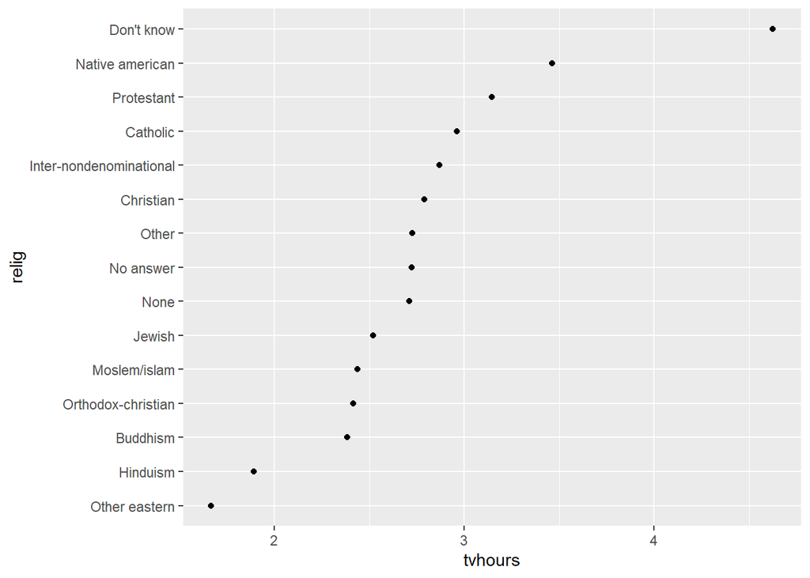

```r
relig_summary %>%
  mutate(relig = fct_reorder(relig, tvhours)) %>%
  ggplot(aes(tvhours, relig)) +
  geom_point()
```

```r
levels(relig_summary$relig)
```

```
##  [1] "No answer"               "Don't know"
##  [3] "Inter-nondenominational" "Native american"
##  [5] "Christian"               "Orthodox-christian"
##  [7] "Moslem/islam"            "Other eastern"
##  [9] "Hinduism"                "Buddhism"
## [11] "Other"                   "None"
## [13] "Jewish"                  "Catholic"
## [15] "Protestant"              "Not applicable"
```

```r
(testlevel <- relig_summary %>%
  mutate(relig = fct_reorder(relig, tvhours)))
```

```
## # A tibble: 15 × 4
##    relig                     age tvhours     n
##    <fct>                   <dbl>   <dbl> <int>
##  1 No answer                49.5    2.72    93
##  2 Don't know               35.9    4.62    15
##  3 Inter-nondenominational  40.0    2.87   109
##  4 Native american          38.9    3.46    23
##  5 Christian                40.1    2.79   689
##  6 Orthodox-christian       50.4    2.42    95
##  7 Moslem/islam             37.6    2.44   104
##  8 Other eastern            45.9    1.67    32
##  9 Hinduism                 37.7    1.89    71
## 10 Buddhism                 44.7    2.38   147
## 11 Other                    41.0    2.73   224
## 12 None                     41.2    2.71  3523
## 13 Jewish                   52.4    2.52   388
## 14 Catholic                 46.9    2.96  5124
## 15 Protestant               49.9    3.15 10846
```

```r
levels(testlevel$relig) #The levels have changed even if the visualization did not.
```

```
##  [1] "Other eastern"           "Hinduism"
##  [3] "Buddhism"                "Orthodox-christian"
##  [5] "Moslem/islam"            "Jewish"
##  [7] "None"                    "No answer"
##  [9] "Other"                   "Christian"
## [11] "Inter-nondenominational" "Catholic"
## [13] "Protestant"              "Native american"
## [15] "Don't know"              "Not applicable"
```

This is most important for plotting

Let’s look at how average age varies across reported income level:

```r
(rincome_summary <- df %>% #Save your df summary as something descriptive
  group_by(rincome) %>% #Group by income so that all summaries will be for those levels
  summarise( #Create summaries for the following:
    age = mean(age, na.rm = TRUE), #Mean age with Na's removed named "age"
    tvhours = mean(tvhours, na.rm = TRUE), #Mean tvhours named "tvhours"
    n = n() #Count number of observations in each column
  ))
```

```
## # A tibble: 16 × 4
##    rincome          age tvhours     n
##    <fct>          <dbl>   <dbl> <int>
##  1 No answer       45.5    2.90   183
##  2 Don't know      45.6    3.41   267
##  3 Refused         47.6    2.48   975
##  4 $25000 or more  44.2    2.23  7363
##  5 $20000 - 24999  41.5    2.78  1283
##  6 $15000 - 19999  40.0    2.91  1048
##  7 $10000 - 14999  41.1    3.02  1168
##  8 $8000 to 9999   41.1    3.15   340
##  9 $7000 to 7999   38.2    2.65   188
## 10 $6000 to 6999   40.3    3.17   215
## 11 $5000 to 5999   37.8    3.16   227
## 12 $4000 to 4999   38.9    3.15   226
## 13 $3000 to 3999   37.8    3.31   276
## 14 $1000 to 2999   34.5    3.00   395
## 15 Lt $1000        40.5    3.36   286
## 16 Not applicable  56.1    3.79  7043
```

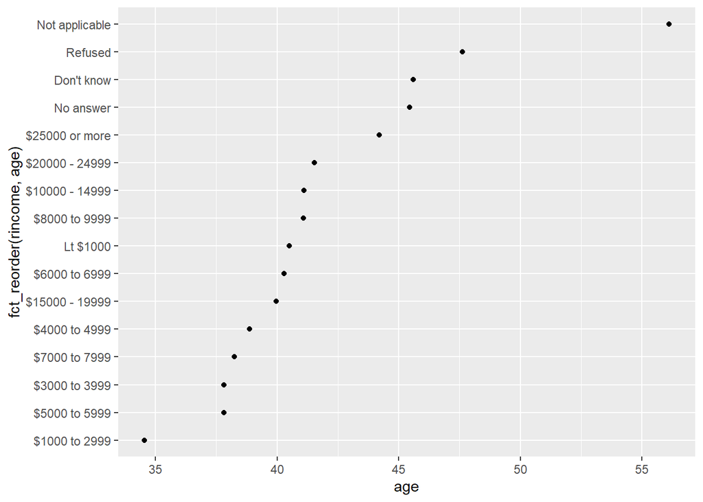

```r
ggplot(rincome_summary, aes(age, fct_reorder(rincome, age))) +
  geom_point()
```

Reported income is an ordinal variable so it should be reported that way However fct_reorder will often create an arbitrary order by the second argument (age in this case).

Use fct_relevel to have an ordered outcome:

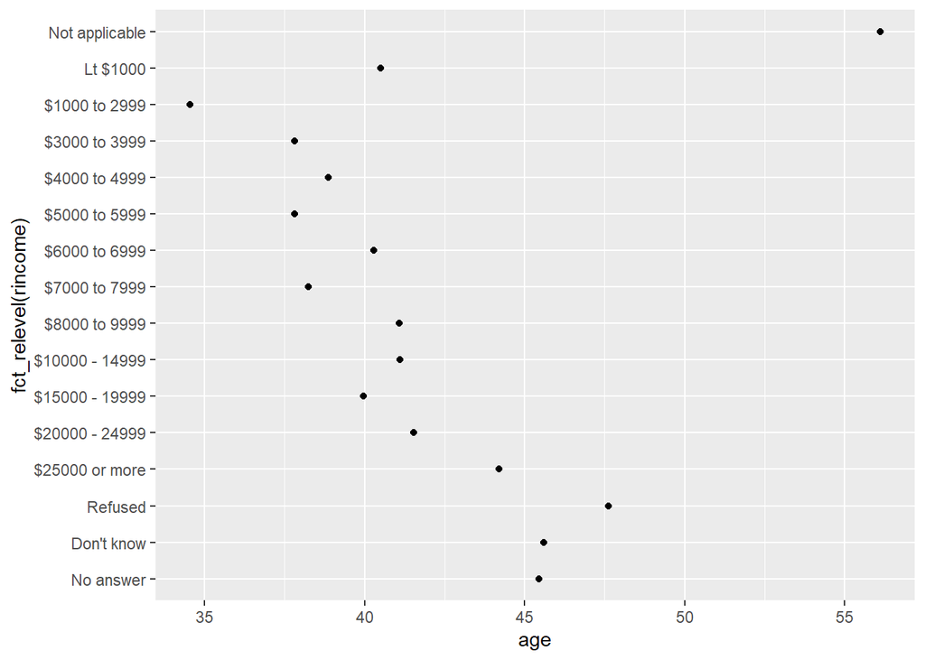

```r
ggplot(rincome_summary, aes(age, fct_relevel(rincome))) +
  geom_point()
```

Now “Not applicable” is up at the top away from the other “special responses” Let’s fix that:

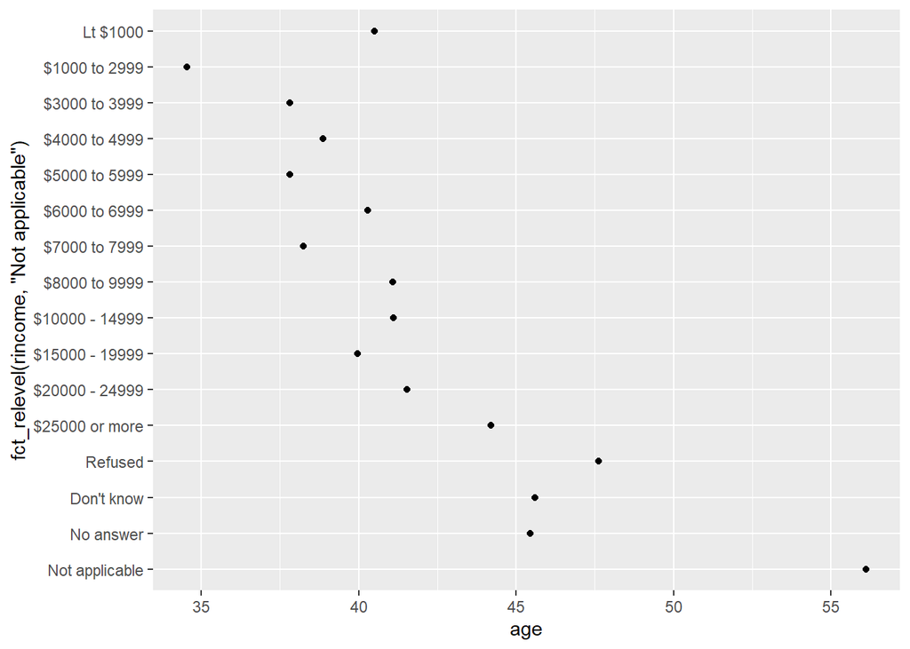

```r
ggplot(rincome_summary, aes(age, fct_relevel(rincome, "Not applicable"))) +
  geom_point()
```

We put it at the end! Now age and income are ordered! However, larger numbers map to the top (Larger is higher in conceptual metaphor theory)

```r
ggplot(rincome_summary, aes(age,x = fct_relevel(desc(rincome), "Not applicable"))) +
  geom_point()
```

This doesn’t work in the aes() function, so we have to do it earlier!

```r
ordered_rincome <-rincome_summary %>%
  mutate(rincome = fct_relevel(rincome, "Not applicable", after = 0))

levels(ordered_rincome$rincome) #not applicable has moved...
```

```
##  [1] "Not applicable" "No answer"      "Don't know"     "Refused"
##  [5] "$25000 or more" "$20000 - 24999" "$15000 - 19999" "$10000 - 14999"
##  [9] "$8000 to 9999"  "$7000 to 7999"  "$6000 to 6999"  "$5000 to 5999"
## [13] "$4000 to 4999"  "$3000 to 3999"  "$1000 to 2999"  "Lt $1000"
```

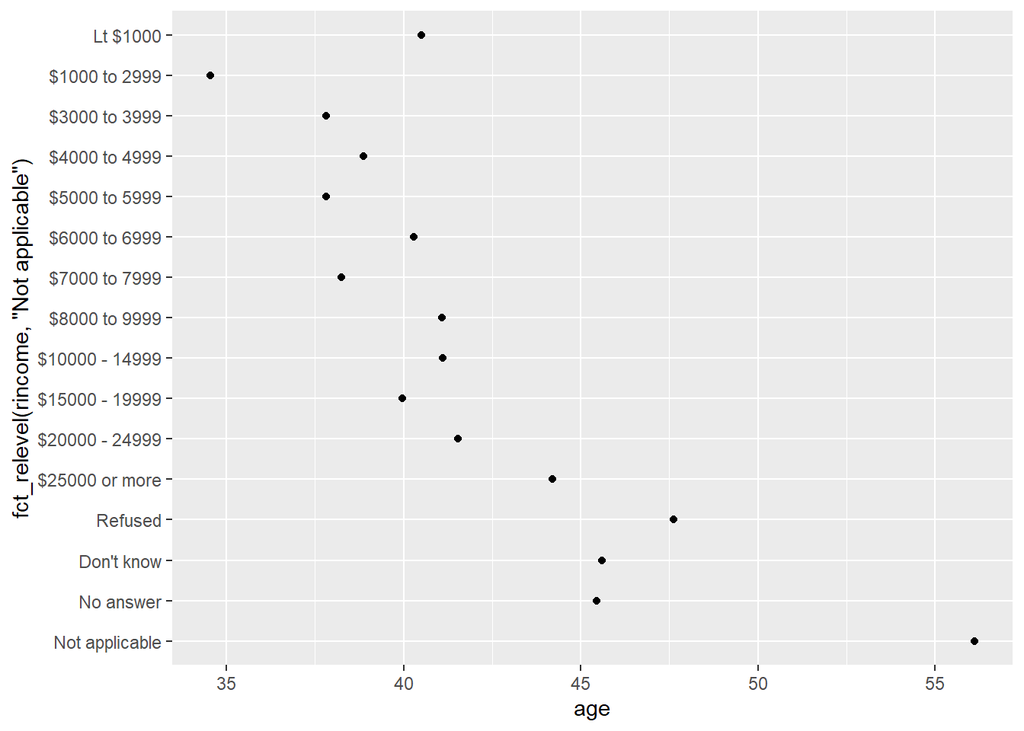

```r
ggplot(ordered_rincome, aes(age, fct_relevel(rincome, "Not applicable"))) +
  geom_point() #But still plotting int he wrong order
```

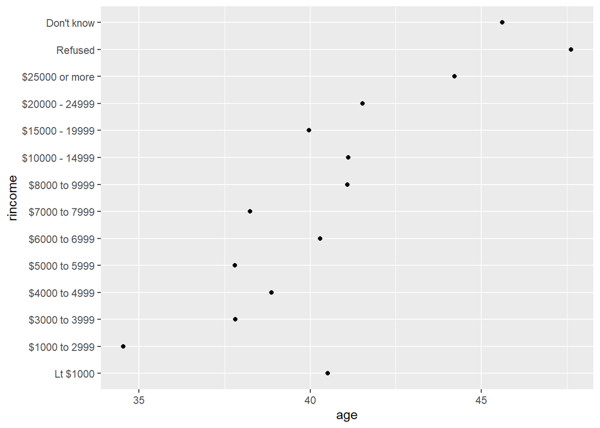

```r
ordered_rincome <- rincome_summary %>%
  mutate(rincome = fct_relevel(rincome, "Not applicable", after = 0)) %>%
  mutate(rincome = fct_rev(rincome)) %>% #Now we can use fct_rev()
  filter(rincome != "Not applicable",
         rincome != "No answer")

ggplot(ordered_rincome, aes(age,rincome)) +
  geom_point()
```

Let’s do some more reordering:

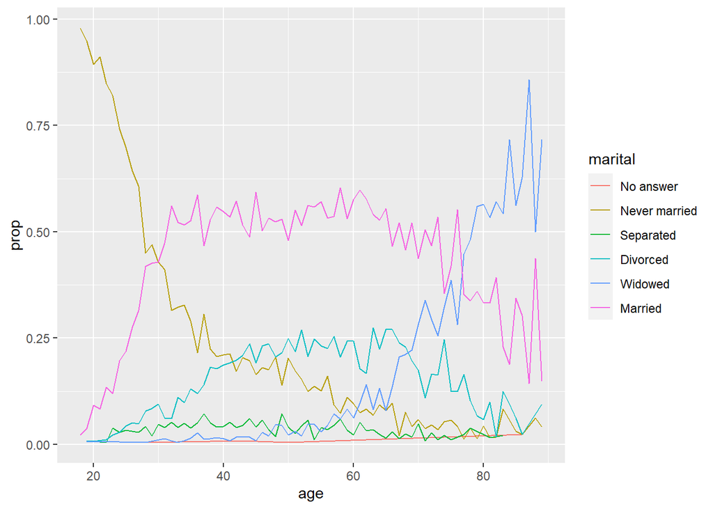

```r
by_age <- data.frame(df) %>% #Get data.frame
  na.omit() %>% #Get rid of Na's in age to do maths
  count(age, marital) %>% # count observations by age and marital status
  group_by(age) %>% #Group by age for the following summary
  mutate(prop = n / sum(n)) #Get proportion of counts per age

ggplot(by_age, aes(age, prop, colour = marital)) +
  geom_line(na.rm = TRUE)
```

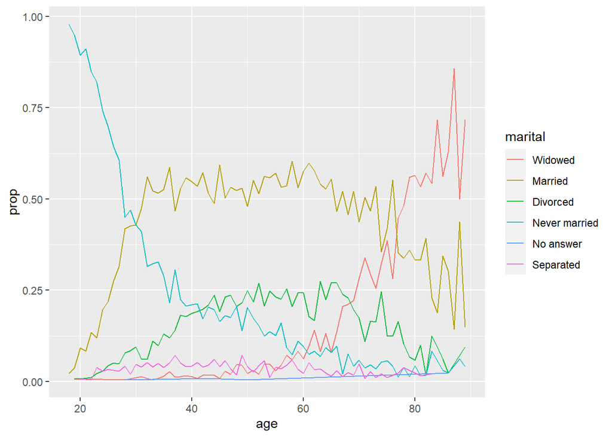

```r
ggplot(by_age, aes(age, prop, colour = fct_reorder2(marital, age, prop))) +
  geom_line() +
  labs(colour = "marital")
```